# Group Project 1

Biology 368/664 Bucknell University

Derek Knight, Jessica Parrino, Margot Beck

21 Feb 2022

## Target Audience

Bucknell 202 biology students interested in public health who are new to R and are looking to explore data analysis.

## Grading

Each student will be expected to complete the following tasks to earn 85% of the points available for this assignment (21/25).

- Identify and obtain suitable dataset
- Use a Github repository and version control to collaborate on the project
- Spend 4-6 hours preparing, coding, and testing tutorial
  - Data exploration (Margot)
  - Data visualization (Derek)
  - Hypothesis testing
- Present tutorial in class
- Provide public archive suitable for sharing to students/faculty

Tutorials from previous classes can be viewed at our public github site: https://github.com/Bucknell-Biol364

Each group should use an *Acknowledgements* section to document the participation of each member and the collaboration within and between groups.

Additional credit will be awarded for providing assistance to other groups and for the development of a tutorial that goes beyond the minimal expectations listed above.

#Coding in R for Bucknell BIOL 202 Students

## Introduction

Welcome to coding in R, biology students! As scientists, you understand that data is everything when it comes to documenting the results of your biology labs, supporting or rejecting a hypothesis in an experiment, or understanding trends in public health (like perhaps transmission trends in a worldwide pandemic). Data doesn’t speak for itself though, it requires a little bit of help on our part. What good does a spreadsheet of numbers, characters, or observations do on its own if you don’t perform some analyses to make sense of it? That is where programs like R come in handy to scientists (or anyone working with datasets, for that matter) as important tools for data exploration, modeling, and analysis. By following along with this R tutorial, you will begin to see how useful coding can be when it comes to working with biological data.

## About the Dataset

The data you will be using for this exercise is the NHANES 2009-2012 dataset. It is survey data from the US National Center for Health Statistics that interviews approximately 5,000 individuals. The interviewees also complete a health examination as part of the survey. 75 variables are included for the 2009-2010 and 2011-2012 sample years.

## Download Packages and Obtain the Dataset

Next, run the below chunk of code line by line. You can do this by hitting “Ctrl+Enter” on each line. You can also click the green arrow in the upper right hand corner of grey box. The first line will load the dataset “NHANES” into your Environment tab (upper right hand window of R-studio). The second line will open up an info page with more information about the NHANES dataset in the Help tab of the lower right hand window of R-studio.

```r
data("NHANES")
help(NHANES)
```

# Data Exploration

Now that you have the relevant packages installed and the dataset downloaded, it’s time to get an idea of what the data are made up of. Run the below code chunk line by line to explore the data. The first function, “summary”, will provide you with a summary of the dataset which includes the minimum, median, mean, maximum, 1st quartile, 3rd quartile, and NA’s for each variable. In the next two lines, the function “head” will show you the first 6 rows of each variable while “tail” will show you the last 6. In the fourth line of code, the function “dim” will display the dimensions of the data table in the form of ‘row, column’. This code chunk should help to give you an idea of what variables make up the data, the size of the dataset, and what the range of observations are for each variable.

```r
summary(NHANES)
```

```
       ID           SurveyYr       Gender          Age          AgeDecade      AgeMonths          Race1           Race3               Education
 Min.   :51624   2009_10:5000   female:5020   Min.   : 0.00    40-49 :1398   Min.   :  0.0   Black   :1197   Asian   : 288   8th Grade     : 451
 1st Qu.:56904   2011_12:5000   male  :4980   1st Qu.:17.00    0-9   :1391   1st Qu.:199.0   Hispanic: 610   Black   : 589   9 - 11th Grade: 888
 Median :62160                                Median :36.00    10-19 :1374   Median :418.0   Mexican :1015   Hispanic: 350   High School   :1517
 Mean   :61945                                Mean   :36.74    20-29 :1356   Mean   :420.1   White   :6372   Mexican : 480   Some College  :2267
 3rd Qu.:67039                                3rd Qu.:54.00    30-39 :1338   3rd Qu.:624.0   Other   : 806   White   :3135   College Grad  :2098
 Max.   :71915                                Max.   :80.00   (Other):2810   Max.   :959.0                   Other   : 158   NA's          :2779
                                                              NA's   : 333   NA's   :5038                    NA's    :5000
      MaritalStatus         HHIncome     HHIncomeMid        Poverty        HomeRooms       HomeOwn             Work          Weight
 Divorced    : 707   more 99999 :2220   Min.   :  2500   Min.   :0.000   Min.   : 1.000   Own  :6425   Looking   : 311   Min.   :  2.80
 LivePartner : 560   75000-99999:1084   1st Qu.: 30000   1st Qu.:1.240   1st Qu.: 5.000   Rent :3287   NotWorking:2847   1st Qu.: 56.10
 Married     :3945   25000-34999: 958   Median : 50000   Median :2.700   Median : 6.000   Other: 225   Working   :4613   Median : 72.70
 NeverMarried:1380   35000-44999: 863   Mean   : 57206   Mean   :2.802   Mean   : 6.249   NA's :  63   NA's      :2229   Mean   : 70.98
 Separated   : 183   45000-54999: 784   3rd Qu.: 87500   3rd Qu.:4.710   3rd Qu.: 8.000                                  3rd Qu.: 88.90
 Widowed     : 456   (Other)    :3280   Max.   :100000   Max.   :5.000   Max.   :13.000                                  Max.   :230.70
 NA's        :2769   NA's       : 811   NA's   :811      NA's   :726     NA's   :69                                      NA's   :78
     Length          HeadCirc         Height           BMI           BMICatUnder20yrs         BMI_WHO         Pulse           BPSysAve
 Min.   : 47.10   Min.   :34.20   Min.   : 83.6   Min.   :12.88   UnderWeight:  55    12.0_18.5   :1277   Min.   : 40.00   Min.   : 76.0
 1st Qu.: 75.70   1st Qu.:39.58   1st Qu.:156.8   1st Qu.:21.58   NormWeight : 805    18.5_to_24.9:2911   1st Qu.: 64.00   1st Qu.:106.0
 Median : 87.00   Median :41.45   Median :166.0   Median :25.98   OverWeight : 193    25.0_to_29.9:2664   Median : 72.00   Median :116.0
 Mean   : 85.02   Mean   :41.18   Mean   :161.9   Mean   :26.66   Obese      : 221    30.0_plus   :2751   Mean   : 73.56   Mean   :118.2
 3rd Qu.: 96.10   3rd Qu.:42.92   3rd Qu.:174.5   3rd Qu.:30.89   NA's       :8726    NA's        : 397   3rd Qu.: 82.00   3rd Qu.:127.0
 Max.   :112.20   Max.   :45.40   Max.   :200.4   Max.   :81.25                                           Max.   :136.00   Max.   :226.0
 NA's   :9457     NA's   :9912    NA's   :353     NA's   :366                                             NA's   :1437     NA's   :1449
    BPDiaAve          BPSys1          BPDia1           BPSys2          BPDia2           BPSys3          BPDia3       Testosterone       DirectChol
 Min.   :  0.00   Min.   : 72.0   Min.   :  0.00   Min.   : 76.0   Min.   :  0.00   Min.   : 76.0   Min.   :  0.0   Min.   :   0.25   Min.   :0.390
 1st Qu.: 61.00   1st Qu.:106.0   1st Qu.: 62.00   1st Qu.:106.0   1st Qu.: 60.00   1st Qu.:106.0   1st Qu.: 60.0   1st Qu.:  17.70   1st Qu.:1.090
 Median : 69.00   Median :116.0   Median : 70.00   Median :116.0   Median : 68.00   Median :116.0   Median : 68.0   Median :  43.82   Median :1.290
 Mean   : 67.48   Mean   :119.1   Mean   : 68.28   Mean   :118.5   Mean   : 67.66   Mean   :117.9   Mean   : 67.3   Mean   : 197.90   Mean   :1.365
 3rd Qu.: 76.00   3rd Qu.:128.0   3rd Qu.: 76.00   3rd Qu.:128.0   3rd Qu.: 76.00   3rd Qu.:126.0   3rd Qu.: 76.0   3rd Qu.: 362.41   3rd Qu.:1.580
 Max.   :116.00   Max.   :232.0   Max.   :118.00   Max.   :226.0   Max.   :118.00   Max.   :226.0   Max.   :116.0   Max.   :1795.60   Max.   :4.030
 NA's   :1449     NA's   :1763    NA's   :1763     NA's   :1647    NA's   :1647     NA's   :1635    NA's   :1635    NA's   :5874      NA's   :1526
    TotChol         UrineVol1       UrineFlow1        UrineVol2       UrineFlow2     Diabetes     DiabetesAge        HealthGen    DaysPhysHlthBad
 Min.   : 1.530   Min.   :  0.0   Min.   : 0.0000   Min.   :  0.0   Min.   : 0.000   No  :9098   Min.   : 1.00   Excellent: 878   Min.   : 0.000
 1st Qu.: 4.110   1st Qu.: 50.0   1st Qu.: 0.4030   1st Qu.: 52.0   1st Qu.: 0.475   Yes : 760   1st Qu.:40.00   Vgood    :2508   1st Qu.: 0.000
 Median : 4.780   Median : 94.0   Median : 0.6990   Median : 95.0   Median : 0.760   NA's: 142   Median :50.00   Good     :2956   Median : 0.000
 Mean   : 4.879   Mean   :118.5   Mean   : 0.9793   Mean   :119.7   Mean   : 1.149               Mean   :48.42   Fair     :1010   Mean   : 3.335
 3rd Qu.: 5.530   3rd Qu.:164.0   3rd Qu.: 1.2210   3rd Qu.:171.8   3rd Qu.: 1.513               3rd Qu.:58.00   Poor     : 187   3rd Qu.: 3.000
 Max.   :13.650   Max.   :510.0   Max.   :17.1670   Max.   :409.0   Max.   :13.692               Max.   :80.00   NA's     :2461   Max.   :30.000
 NA's   :1526     NA's   :987     NA's   :1603      NA's   :8522    NA's   :8524                 NA's   :9371                     NA's   :2468
```

[output cut: 17 more lines]

```
 No  :4024   Non-Smoker:4024   Min.   : 6.00   No  :2049   Min.   : 1.00   No  :3575    Min.   : 5.00   No  :4700   No  : 223   Min.   : 9.00
 Yes :3211   Smoker    :3211   1st Qu.:15.00   Yes :2892   1st Qu.:15.00   Yes :1366    1st Qu.:15.00   Yes :1065   Yes :5544   1st Qu.:15.00
 NA's:2765   NA's      :2765   Median :17.00   NA's:5059   Median :16.00   NA's:5059    Median :17.00   NA's:4235   NA's:4233   Median :17.00
                               Mean   :17.83               Mean   :17.02                Mean   :17.69                           Mean   :17.43
                               3rd Qu.:19.00               3rd Qu.:19.00                3rd Qu.:19.00                           3rd Qu.:19.00
                               Max.   :72.00               Max.   :48.00                Max.   :52.00                           Max.   :50.00
                               NA's   :6920                NA's   :7109                 NA's   :8634                            NA's   :4460
 SexNumPartnLife   SexNumPartYear   SameSex          SexOrientation  PregnantNow
 Min.   :   0.00   Min.   : 0.000   No  :5353   Bisexual    : 119   Yes    :  72
 1st Qu.:   2.00   1st Qu.: 1.000   Yes : 415   Heterosexual:4638   No     :1573
 Median :   5.00   Median : 1.000   NA's:4232   Homosexual  :  85   Unknown:  51
 Mean   :  15.09   Mean   : 1.342               NA's        :5158   NA's   :8304
 3rd Qu.:  12.00   3rd Qu.: 1.000
 Max.   :2000.00   Max.   :69.000
 NA's   :4275      NA's   :5072
```

```r
head(NHANES)
```

| ID | SurveyYr | Gender | Age | AgeDecade | AgeMonths | Race1 | Race3 | Education | MaritalStatus | HHIncome | HHIncomeMid | Poverty | HomeRooms | HomeOwn | Work | Weight | Length | HeadCirc | Height | BMI | BMICatUnder20yrs | BMI_WHO | Pulse | BPSysAve | BPDiaAve | BPSys1 | BPDia1 | BPSys2 | BPDia2 | … |
| --- | --- | --- | --- | --- | --- | --- | --- | --- | --- | --- | --- | --- | --- | --- | --- | --- | --- | --- | --- | --- | --- | --- | --- | --- | --- | --- | --- | --- | --- | --- |
| 51624 | 2009_10 | male | 34 | 30-39 | 409 | White | NA | High School | Married | 25000-34999 | 30000 | 1.36 | 6 | Own | NotWorking | 87.4 | NA | NA | 164.7 | 32.22 | NA | 30.0_plus | 70 | 113 | 85 | 114 | 88 | 114 | 88 | … |
| 51624 | 2009_10 | male | 34 | 30-39 | 409 | White | NA | High School | Married | 25000-34999 | 30000 | 1.36 | 6 | Own | NotWorking | 87.4 | NA | NA | 164.7 | 32.22 | NA | 30.0_plus | 70 | 113 | 85 | 114 | 88 | 114 | 88 | … |
| 51624 | 2009_10 | male | 34 | 30-39 | 409 | White | NA | High School | Married | 25000-34999 | 30000 | 1.36 | 6 | Own | NotWorking | 87.4 | NA | NA | 164.7 | 32.22 | NA | 30.0_plus | 70 | 113 | 85 | 114 | 88 | 114 | 88 | … |
| 51625 | 2009_10 | male | 4 | 0-9 | 49 | Other | NA | NA | NA | 20000-24999 | 22500 | 1.07 | 9 | Own | NA | 17.0 | NA | NA | 105.4 | 15.30 | NA | 12.0_18.5 | NA | NA | NA | NA | NA | NA | NA | … |
| 51630 | 2009_10 | female | 49 | 40-49 | 596 | White | NA | Some College | LivePartner | 35000-44999 | 40000 | 1.91 | 5 | Rent | NotWorking | 86.7 | NA | NA | 168.4 | 30.57 | NA | 30.0_plus | 86 | 112 | 75 | 118 | 82 | 108 | 74 | … |
| 51638 | 2009_10 | male | 9 | 0-9 | 115 | White | NA | NA | NA | 75000-99999 | 87500 | 1.84 | 6 | Rent | NA | 29.8 | NA | NA | 133.1 | 16.82 | NA | 12.0_18.5 | 82 | 86 | 47 | 84 | 50 | 84 | 50 | … |

```r
tail(NHANES)
```

| ID | SurveyYr | Gender | Age | AgeDecade | AgeMonths | Race1 | Race3 | Education | MaritalStatus | HHIncome | HHIncomeMid | Poverty | HomeRooms | HomeOwn | Work | Weight | Length | HeadCirc | Height | BMI | BMICatUnder20yrs | BMI_WHO | Pulse | BPSysAve | BPDiaAve | BPSys1 | BPDia1 | BPSys2 | BPDia2 | … |
| --- | --- | --- | --- | --- | --- | --- | --- | --- | --- | --- | --- | --- | --- | --- | --- | --- | --- | --- | --- | --- | --- | --- | --- | --- | --- | --- | --- | --- | --- | --- |
| 71909 | 2011_12 | male | 28 | 20-29 | NA | Mexican | Mexican | 9 - 11th Grade | NeverMarried | 5000-9999 | 7500 | 0.46 | 3 | Rent | Working | 92.3 | NA | NA | 177.3 | 29.4 | NA | 25.0_to_29.9 | 68 | 124 | 65 | 124 | 62 | 126 | 64 | … |
| 71909 | 2011_12 | male | 28 | 20-29 | NA | Mexican | Mexican | 9 - 11th Grade | NeverMarried | 5000-9999 | 7500 | 0.46 | 3 | Rent | Working | 92.3 | NA | NA | 177.3 | 29.4 | NA | 25.0_to_29.9 | 68 | 124 | 65 | 124 | 62 | 126 | 64 | … |
| 71910 | 2011_12 | female | 0 | 0-9 | 5 | White | White | NA | NA | 75000-99999 | 87500 | 3.37 | 10 | Own | NA | 6.7 | 67.6 | 42.2 | NA | NA | NA | NA | NA | NA | NA | NA | NA | NA | NA | … |
| 71911 | 2011_12 | male | 27 | 20-29 | NA | Mexican | Mexican | College Grad | Married | 75000-99999 | 87500 | 3.25 | 10 | Own | Working | 96.7 | NA | NA | 175.8 | 31.3 | NA | 30.0_plus | 74 | 133 | 74 | 122 | 76 | 132 | 82 | … |
| 71915 | 2011_12 | male | 60 | 60-69 | NA | White | White | College Grad | NeverMarried | 65000-74999 | 70000 | 5.00 | 4 | Own | Working | 78.4 | NA | NA | 168.8 | 27.5 | NA | 25.0_to_29.9 | 76 | 147 | 73 | 150 | 72 | 148 | 74 | … |
| 71915 | 2011_12 | male | 60 | 60-69 | NA | White | White | College Grad | NeverMarried | 65000-74999 | 70000 | 5.00 | 4 | Own | Working | 78.4 | NA | NA | 168.8 | 27.5 | NA | 25.0_to_29.9 | 76 | 147 | 73 | 150 | 72 | 148 | 74 | … |

```r
dim(NHANES)
```

```
[1] 10000    76
```

You can also look at the summary of just a single column. You can type the dataset (in this case NHANES) followed by a dollar sign with the column you are interested (in this case MaritalStatus.

```r
summary(NHANES$MaritalStatus)
```

```
    Divorced  LivePartner      Married NeverMarried    Separated      Widowed         NA's
         707          560         3945         1380          183          456         2769
```

```r
head(NHANES$MaritalStatus)
```

```
[1] Married     Married     Married     <NA>        LivePartner <NA>
Levels: Divorced LivePartner Married NeverMarried Separated Widowed
```

```r
tail(NHANES$MaritalStatus)
```

```
[1] NeverMarried NeverMarried <NA>         Married      NeverMarried NeverMarried
Levels: Divorced LivePartner Married NeverMarried Separated Widowed
```

Let’s try to write code youself! Look for the summary of just the column Race1:

# Data Visualization

After exploring the dataset, it is essential to visualize it. Here is a silly example that Professor Field showed us in our Data Analysis course. If you look at the mean of x, mean of y, standard deviation of x, and standard deviation of y, and correlation between x and y, all of the data looks similar.

```r
datasaurus_dozen %>%
  group_by(dataset) %>%
  summarize(
      mean_x    = mean(x),
      mean_y    = mean(y),
      std_dev_x = sd(x),
      std_dev_y = sd(y),
      corr_x_y  = cor(x, y)
      )
```

[output not shown]

```r
  ggplot(datasaurus_dozen, aes(x = x, y = y, colour = dataset))+
    geom_point()+
    theme_void()+
    theme(legend.position = "none")+
    facet_wrap(~dataset, ncol = 3)
```

[output not shown]

To visualize the NHANES dataset, we can look at the spread of a numeric variable using a jitterplot and a boxplot. The boxplot provides information on the sumarry statistics, and the jitterplot shows where each individual data point lies. We can use boxplots and jitterplots to visualize the differences in the numeric variable for different categorical variables. For this example, we are looking at height for the various races. Now look at the code. you can see we are using a command from the ggplot2 package. We are making Race the x-axis and Height the y-axis. We have a boxplot and a jitterplot on the graph (the size command changes the size of each point and alpha changes how dark each point is). We are suing the cowplot package theme, and we titled the x and y axis.

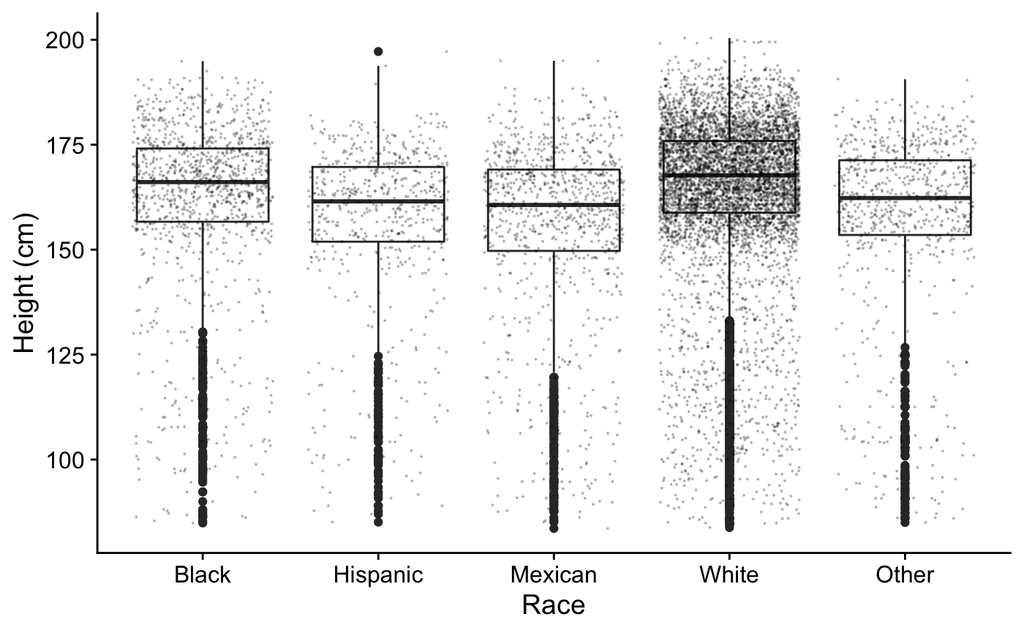

```r
ggplot(NHANES) +
  aes(x = Race1, y = Height) +
  geom_boxplot() +
  geom_jitter(color="black", size=0.1, alpha=0.2) +
  theme_cowplot() +
  xlab("Race") +
  ylab("Height (cm)")
```

Now, let’s try making a boxplot for yourself. Try to make boxplots of BMI for the two different genders below.

We can also visualize the difference between two numeric variables. For this, we can make a scatterplot. Looking at the code, we put Height on the x-axis and Pulse on the y-axis. We can change the points size and transparency (alpha), and label different axis as well.

[figure not shown]

```r
ggplot(NHANES, aes(x = Height, y = Pulse)) +
  geom_point(aes(colour = "black"),
             position = "jitter",
             alpha = 0.8,
             size=0.05) +
  xlab("Pulse") +
  ylab("Height")
```

```r
  theme_cowplot()
```

[output not shown]

[output cut: 333 more lines]

[output not shown]

You can also color code the data points to change by gender. You can find the code for that below. Here, we told it to change the color of the datapoints based on Gender.

[figure not shown]

```r
ggplot(NHANES, aes(x = Height, y = Pulse)) +
  geom_point(aes(colour = factor(Gender)),
             position = "jitter",
             alpha = 0.8,
             size=0.05) +
  xlab("Pulse") +
  ylab("Height")
```

```r
  theme_cowplot()
```

[output not shown]

[output cut: 333 more lines]

[output not shown]

You can also add a linear regression trendline to the graph. You can see the code for that below. We added a geom_smooth command with the method “lm”, meaning linear model. We had the colors of the linear model lines match the gender.

```
Warning: Removed 1490 rows containing non-finite values (stat_smooth).
Warning: Removed 1490 rows containing missing values (geom_point).
```

[figure not shown]

```r
ggplot(NHANES, aes(x = Height, y = Pulse)) +
  geom_point(aes(colour = factor(Gender)),
             position = "jitter",
             alpha = 0.8,
             size=0.05) +
  geom_smooth(method='lm',aes(group = factor(Gender),
                              colour = factor(Gender))) +
  xlab("Pulse") +
  ylab("Height")
```

```r
  theme_cowplot()
```

[output not shown]

[output cut: 333 more lines]

[output not shown]

Let’s have you try a graph! Make a scatterplot with BMI and pulse below:

Now, use that code to separate the scatterplot with BMI and pulse based on gender:

Now, take that line of code for the scatterplot with BMI and pulse and add linear model lines for the two genders:

# Hypothesis Testing

Now that we have explored and visualized the data, we can form hypothesis and test them in order to see how (if at all) our data is correlated. For example, lets look at two quantitative variables SleepHrsNight (self-reported number of hours study participant usually gets at night on weekdays or workdays, reported for participants aged 16 years and older) and PhysActiveDays (Number of days in a typical week that participant does moderate or vigorous-intensity activity, reported for participants 12 years or older).

For this example, the null hypothesis is there is no correlation between number of hours slept per night and exercise. The alternative hypothesis would be number of hours slept per night is correlated to exercise.

## Shapiro Testing

```r
shapiro.test(NHANES$PhysActiveDays)
```

[output not shown]

## Transforming the data

```r
log_PhysActiveDays <- log(NHANES$PhysActiveDays)
hist(log(NHANES$PhysActiveDays))
```

[output not shown]

## Linear Model

Now that the data is normally distributed, we can run what is called a linear model in order to reject or accept our hypothesis. Linear models describe a continuous response variable as a function of one or more predictor variables. It is a regression model that uses a straight line to describe the relationship between variables (in this case the relationship between hours slept and exercise). It finds the line of best fit through your data by searching for the value of the regression coefficient(s) that minimizes the total error of the model. The next code chunk is telling R to analyze if hours spent exercising effects hours slept. Run the next chunk and pay close attention to it’s p-value.

```r
lmPhysActiveDays <- lm(SleepHrsNight~log_PhysActiveDays, data=NHANES)
summary(lmPhysActiveDays)
```

[output not shown]

Now, let’s try to do a linear model yourself! Think of two variables you believe could be correlated with each other, and use a linear model to test if they are:

# Conclusion

This tutorial was created in order to begin to get you to think about and familiarize yourself with R and data exploration. We took quite a large data set, explored and visualized it, formulated a hypothesis and assigned meaning to a large quantity of data. It is okay if your hypotheses are incorrect, or the outcome is not what you predicted. This outcome is still valuable because you gain more information about your dataset, and can formulate new questions and hypotheses to explore and verify.

# Acknowledgements

The information about the NHANES dataset was found on the ‘help’ page for NHANES in R.

Margot Beck wrote the introduction and data exploration sections.

Code used for exploring the data was inspired by a blog post on R-bloggers (https://www.r-bloggers.com/2018/11/explore-your-dataset-in-r/).

Code for hypothesis testing was inspired by Homeworks 1 and 2.

Jessica Parrino wrote the hypothesis testing and conclusion sections.

Derek Knight wrote the Data Visualization section and the inserts of open code for the student to try.

DatasauRus package and description below: Stephanie Locke https://github.com/jumpingrivers/datasauRus

The datasauRus package wraps the awesome Datasaurus Dozen dataset, which contains 13 sets of x-y data. Each sub-dataset has five statistics that are (almost) the same in each case. (These are the mean of x, mean of y, standard deviation of x, standard deviation of y, and Pearson correlation between x and y). However, scatter plots reveal that each sub-dataset looks very different. The dataset is intended to be used to teach students that it is important to plot their own datasets, rather than relying only on statistics.

The Datasaurus was created by Alberto Cairo in this great [blog post](http://www.thefunctionalart.com/2016/08/download-datasaurus-never-trust-summary.html).

He’s been subsequently made even more famous in the paper [Same Stats, Different Graphs: Generating Datasets with Varied Appearance and Identical Statistics through Simulated Annealing](https://www.autodeskresearch.com/publications/samestats) by Justin Matejka and George Fitzmaurice.

In the paper, Justin and George simulate a variety of datasets that the same summary statistics to the Datasaurus but have very different distributions.

This package also makes these datasets available for use as an advanced [Anscombe’s Quartet](https://en.wikipedia.org/wiki/Anscombe%27s_quartet), available in R as `anscombe`.